# Final Assignment

Emily Allgire

2022-08-04

# Identifying risk factors for high blood pressure

### The Question

Our goal is to identify risk factors for hypertension to identify populations of concern. Hypertension is also known as **high blood pressure**. It is identified via *systolic pressure* (pressure with which the heart pushes out blood) and *diastolic pressure* (pressure with which the heart refills with blood).

For this study, we collected data on: age, gender, height, weight, bmi and ran a pearson correlation on these factors with systolic and diastolic blood pressure.

### Analysis

Sample Demographics

| Category | Age | Height | Weight | BMI |
| --- | --- | --- | --- | --- |
| Mean (SD) | 35 (12.52) | 160.77 (10.12) | 84.61 (11.53) | 33.19 (6.47) |

### Results

Running a pearson correlation between various continuous demographic information and systolic and diastolic blood pressure, all correlated positively except for height which was negatively correlated (**Fig. 1**).

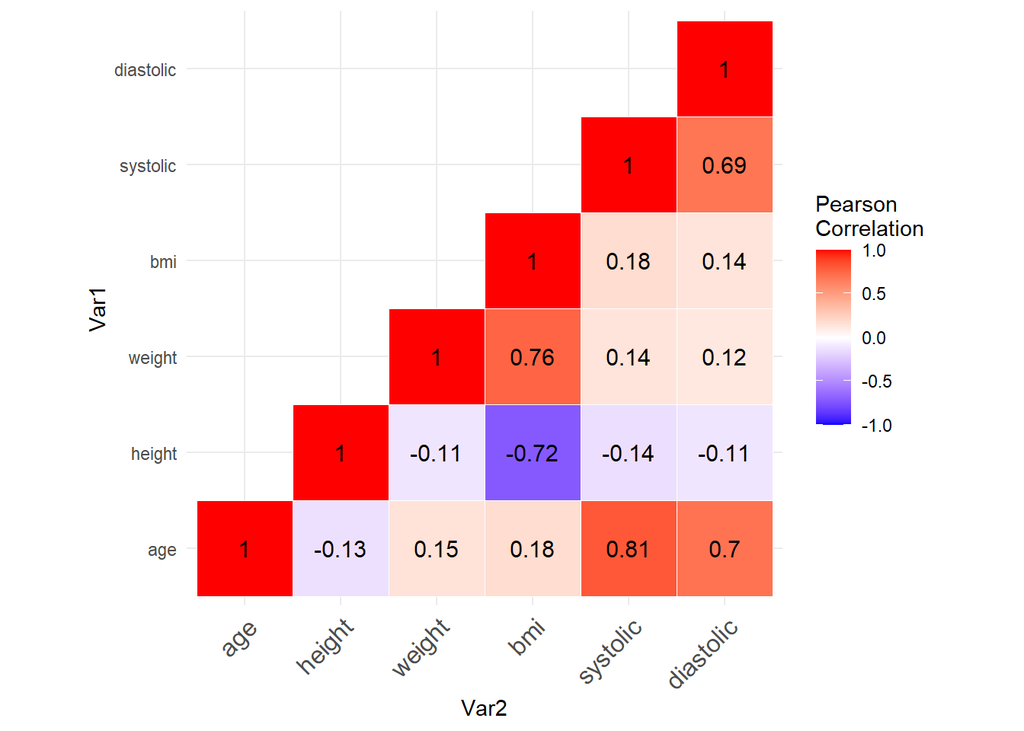

Fig. 1: Correlation matrix representing data from sample

Age was the strongest correlation with systolic (r=0.81,p=2.2e-16) and diastolic (r=0.70,p=2.2e-16). However, with age, “healthy” blood pressure increases (**Fig. 2**). Thus, increased blood pressure is not necessarily an indicator of increased frequencies of high blood pressure.

[figure not shown]

Fig. 2: Blood Pressure by Age. Data sourced from the American Heart Association

BMI and Weight, which are themselves tightly correlated, have similar correlations to systolic and diastolic blood pressure. However, these are very weak correlations, and though a potential indicator of high blood pressure, they could not be reliably used to identify populations at risk for hypertension.

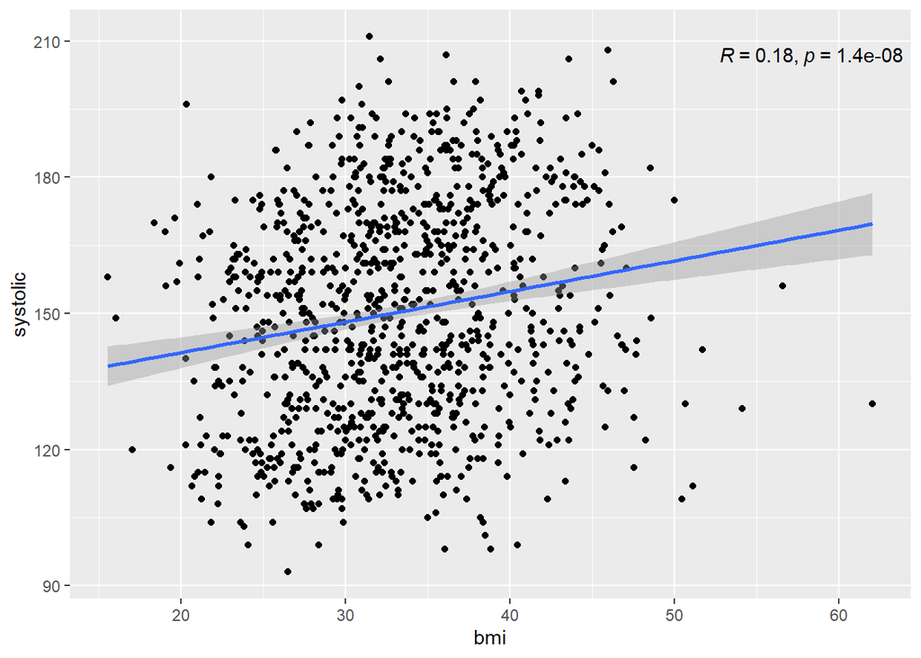

Fig. 3: Dot plot representing correlation between BMI and systolic blood pressure

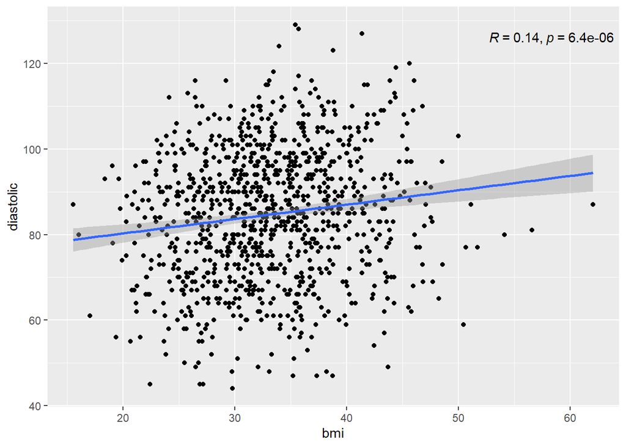

Fig. 4: Dot plot representing correlation between BMI and diastolic blood pressure

### Conclusions

From these data, we did not find a reliable indicator of hypertension. Data does suggest increased BMI may be a risk factor for hypertension, but a better indicator of high blood pressure would be ideal. In future studies, further demographic information should be studied to find variables more closely correlated to high blood pressure.